# Monitoramento das Funções Orçamentárias

Thais G. Veras Gama

11/09/2021

# 1 Funções

Esse relatório apresenta a execução orçamentária por função para Prefeitura de Fortaleza.

Os valores monetários considerados foram corrigidos pelo índice de preços IPCA a preços de janeiro de 2021.

As despesas executadas incluem as intraorçamentárias.

## 1.1 LEGISLATIVA:

**Função:** LEGISLATIVA

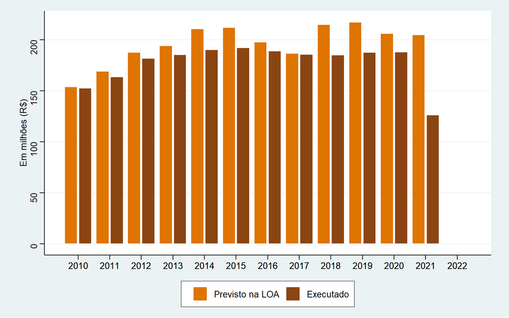

| ANO | PREVISTO NA LOA | EXECUTADO | LOA NOMINAL | EXECUTADO NOMINAL | % EXECUTADO |
| --- | --- | --- | --- | --- | --- |
| 2010 | R$ 153.869.376,60 | R$ 152.389.911,96 | R$ 83.500.976,00 | R$ 82.698.108,37 | 99.04 |
| 2011 | R$ 169.147.931,87 | R$ 163.510.183,02 | R$ 97.215.976,00 | R$ 93.975.739,77 | 96.67 |
| 2012 | R$ 187.404.133,93 | R$ 181.598.586,12 | R$ 114.713.200,00 | R$ 111.159.527,23 | 96.90 |
| 2013 | R$ 194.125.925,64 | R$ 185.145.806,49 | R$ 125.765.590,00 | R$ 119.947.768,50 | 95.37 |
| 2014 | R$ 210.495.174,82 | R$ 190.265.495,80 | R$ 144.430.930,00 | R$ 130.550.367,86 | 90.39 |
| 2015 | R$ 212.004.163,26 | R$ 192.089.624,63 | R$ 154.787.032,00 | R$ 140.247.165,04 | 90.61 |
| 2016 | R$ 197.453.671,46 | R$ 188.977.374,15 | R$ 159.550.140,00 | R$ 152.700.966,66 | 95.71 |
| 2017 | R$ 186.491.889,92 | R$ 185.632.463,41 | R$ 160.168.133,00 | R$ 159.430.016,51 | 99.54 |
| 2018 | R$ 214.747.795,93 | R$ 184.859.696,27 | R$ 189.871.749,00 | R$ 163.445.839,80 | 86.08 |
| 2019 | R$ 217.207.538,93 | R$ 187.440.955,09 | R$ 199.239.819,00 | R$ 171.935.569,78 | 86.30 |
| 2020 | R$ 206.077.177,40 | R$ 187.895.638,56 | R$ 197.170.103,00 | R$ 179.774.407,22 | 91.18 |
| 2021 | R$ 204.693.321,00 | R$ 126.091.853,50 | R$ 204.693.321,00 | R$ 126.091.853,50 | 61.60 |

**Valor previsto no PPA para 2022:** R$ 210.342.509,00

**Percentual de gasto em relação ao total das despesas:**

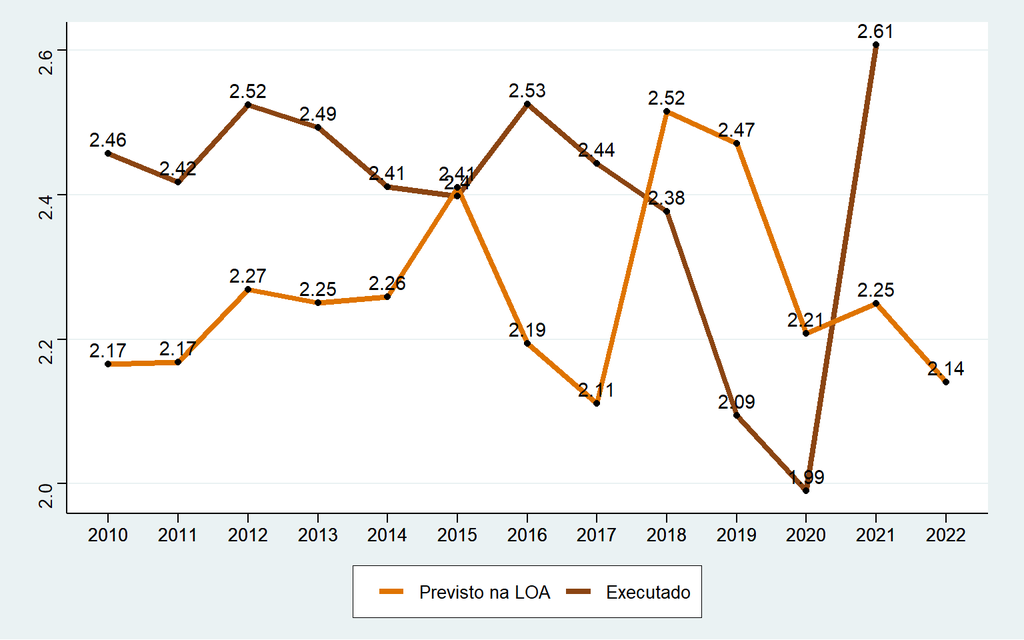

## 1.2 JUDICIÁRIA:

**Função:** JUDICIARIA

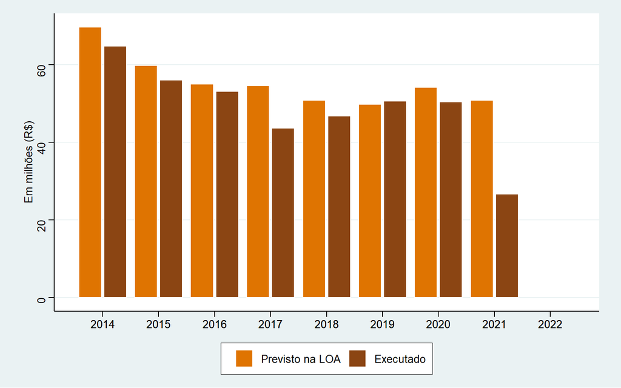

| ANO | PREVISTO NA LOA | EXECUTADO | LOA NOMINAL | EXECUTADO NOMINAL | % EXECUTADO |
| --- | --- | --- | --- | --- | --- |
| 2014 | R$ 69.745.703,91 | R$ 64.772.230,20 | R$ 47.855.904,00 | R$ 44.443.362,91 | 92.87 |
| 2015 | R$ 59.853.294,95 | R$ 56.019.544,13 | R$ 43.699.679,00 | R$ 40.900.607,03 | 93.59 |
| 2016 | R$ 54.994.261,96 | R$ 53.102.594,85 | R$ 44.437.473,00 | R$ 42.908.933,42 | 96.56 |
| 2017 | R$ 54.552.260,35 | R$ 43.646.550,99 | R$ 46.852.084,00 | R$ 37.485.740,46 | 80.01 |
| 2018 | R$ 50.870.177,33 | R$ 46.741.176,46 | R$ 44.977.456,00 | R$ 41.326.752,09 | 91.88 |
| 2019 | R$ 49.800.699,46 | R$ 50.667.062,49 | R$ 45.681.114,00 | R$ 46.475.810,23 | 101.74 |
| 2020 | R$ 54.131.647,83 | R$ 50.464.189,96 | R$ 51.791.968,00 | R$ 48.283.025,12 | 93.22 |
| 2021 | R$ 50.867.225,00 | R$ 26.698.095,13 | R$ 50.867.225,00 | R$ 26.698.095,13 | 52.49 |

**Valor previsto no PPA para 2022:** R$ 51.239.733,00

**Percentual de gasto em relação ao total das despesas:**

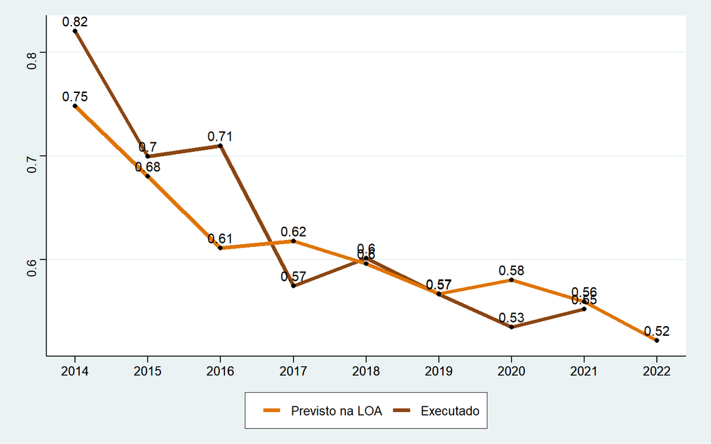

## 1.3 ESSENCIAL À JUSTIÇA:

**Função:** ESSENCIAL A JUSTICA

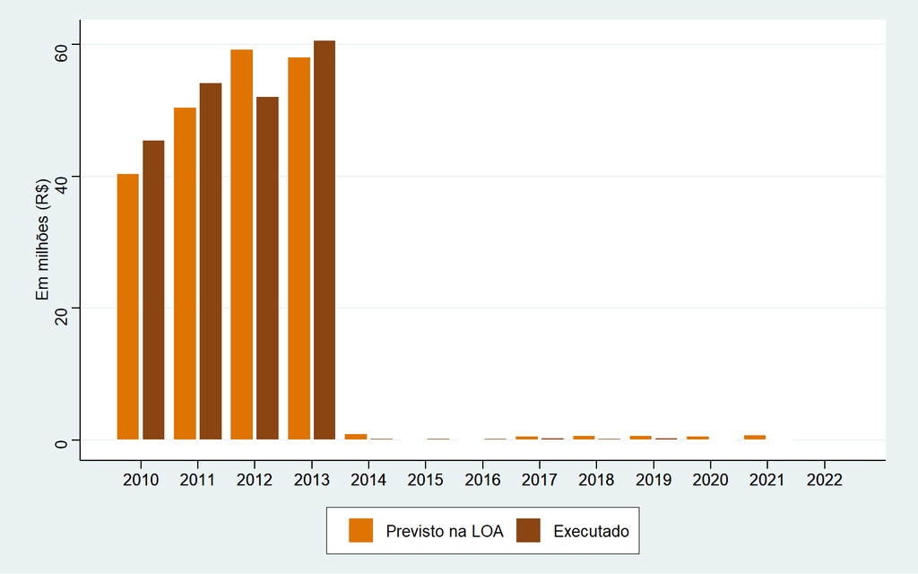

| ANO | PREVISTO NA LOA | EXECUTADO | LOA NOMINAL | EXECUTADO NOMINAL | % EXECUTADO |
| --- | --- | --- | --- | --- | --- |
| 2010 | R$ 40.441.537,04 | R$ 45.465.426,45 | R$ 21.946.588,00 | R$ 24.672.924,31 | 112.42 |
| 2011 | R$ 50.461.947,54 | R$ 54.182.230,23 | R$ 29.002.468,00 | R$ 31.140.660,93 | 107.37 |
| 2012 | R$ 59.241.100,61 | R$ 52.077.525,54 | R$ 36.262.467,00 | R$ 31.877.523,07 | 87.91 |
| 2013 | R$ 58.064.927,48 | R$ 60.654.114,77 | R$ 37.617.695,00 | R$ 39.295.114,78 | 104.46 |
| 2014 | R$ 1.020.187,45 | R$ 268.677,35 | R$ 700.000,00 | R$ 184.352,54 | 26.34 |
| 2015 | R$ 146.552,62 | R$ 294.967,11 | R$ 107.000,00 | R$ 215.359,37 | 201.27 |
| 2016 | R$ 136.132,15 | R$ 281.820,01 | R$ 110.000,00 | R$ 227.721,38 | 207.02 |
| 2017 | R$ 685.960,96 | R$ 357.063,92 | R$ 589.136,00 | R$ 306.663,53 | 52.05 |
| 2018 | R$ 727.242,64 | R$ 275.996,96 | R$ 643.000,00 | R$ 244.025,91 | 37.95 |
| 2019 | R$ 732.777,40 | R$ 368.034,26 | R$ 672.161,00 | R$ 337.589,94 | 50.22 |
| 2020 | R$ 677.625,34 | R$ 156.505,20 | R$ 648.337,00 | R$ 149.740,73 | 23.10 |
| 2021 | R$ 834.579,00 | R$ 69.501,47 | R$ 834.579,00 | R$ 69.501,47 | 8.33 |

**Valor previsto no PPA para 2022:** R$ 965.204,00

**Percentual de gasto em relação ao total das despesas:**

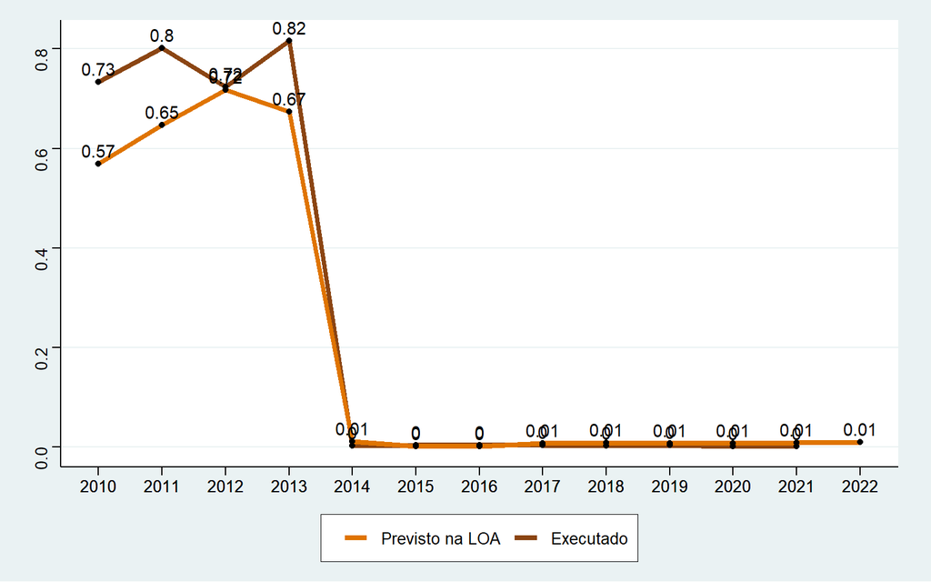

## 1.4 ADMINISTRAÇÃO:

**Função:** ADMINISTRACAO

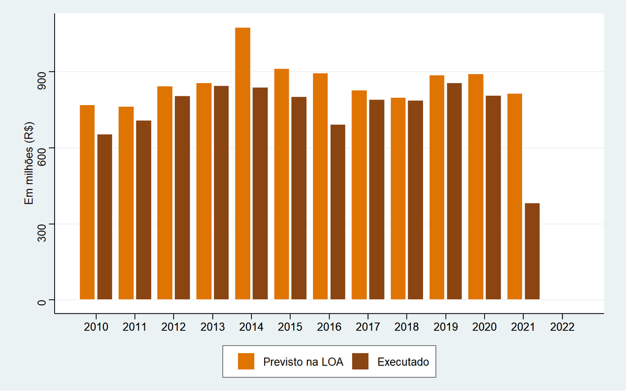

| ANO | PREVISTO NA LOA | EXECUTADO | LOA NOMINAL | EXECUTADO NOMINAL | % EXECUTADO |
| --- | --- | --- | --- | --- | --- |
| 2010 | R$ 769.674.353,75 | R$ 654.391.204,01 | R$ 417.682.590,00 | R$ 355.121.372,61 | 85.02 |
| 2011 | R$ 764.147.283,14 | R$ 708.384.543,70 | R$ 439.185.529,00 | R$ 407.136.487,20 | 92.70 |
| 2012 | R$ 844.502.662,86 | R$ 805.552.454,30 | R$ 516.934.183,00 | R$ 493.092.109,88 | 95.39 |
| 2013 | R$ 856.503.671,63 | R$ 846.380.933,39 | R$ 554.890.797,00 | R$ 548.332.723,20 | 98.82 |
| 2014 | R$ 1.076.187.575,10 | R$ 839.251.505,94 | R$ 738.424.396,00 | R$ 575.851.088,33 | 77.98 |
| 2015 | R$ 912.558.285,56 | R$ 802.636.353,91 | R$ 666.270.824,00 | R$ 586.015.373,87 | 87.95 |
| 2016 | R$ 896.099.473,43 | R$ 692.473.808,26 | R$ 724.082.745,00 | R$ 559.545.397,35 | 77.28 |
| 2017 | R$ 828.297.433,75 | R$ 790.335.259,69 | R$ 711.381.356,00 | R$ 678.777.629,66 | 95.42 |
| 2018 | R$ 799.374.266,83 | R$ 787.922.303,45 | R$ 706.776.009,00 | R$ 696.650.623,05 | 98.57 |
| 2019 | R$ 887.773.757,71 | R$ 857.152.261,45 | R$ 814.335.836,00 | R$ 786.247.393,94 | 96.55 |
| 2020 | R$ 891.826.308,41 | R$ 806.667.843,14 | R$ 853.279.763,00 | R$ 771.802.019,65 | 90.45 |
| 2021 | R$ 814.576.625,00 | R$ 382.136.727,30 | R$ 814.576.625,00 | R$ 382.136.727,30 | 46.91 |

**Valor previsto no PPA para 2022:** R$ 878.388.193,00

**Percentual de gasto em relação ao total das despesas:**

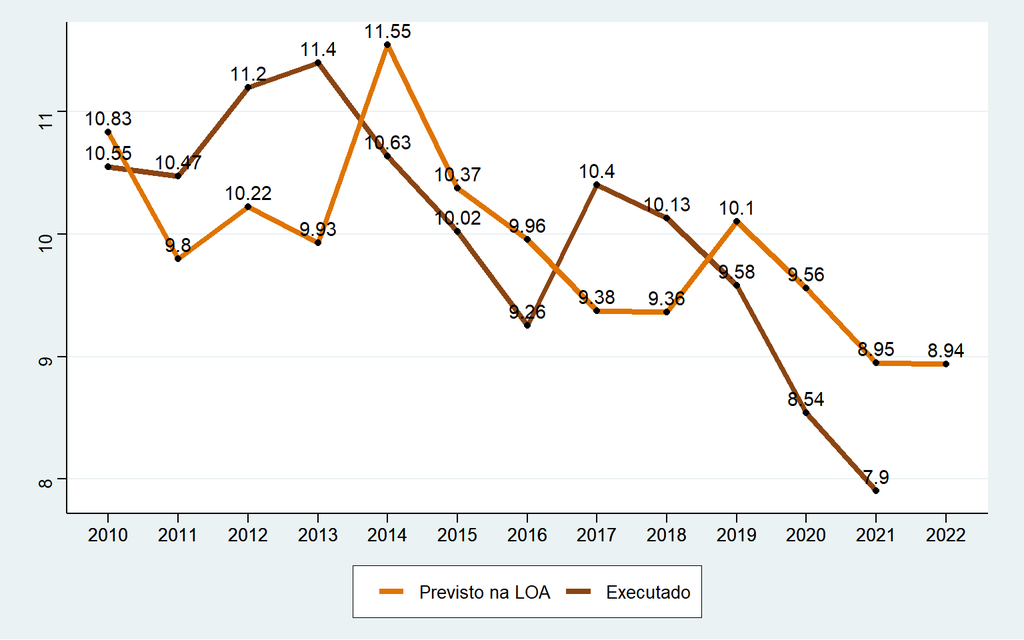

## 1.5 SEGURANÇA PÚBLICA:

**Função:** SEGURANCA PUBLICA

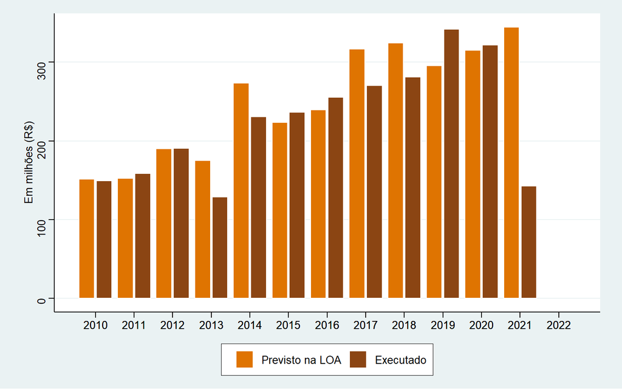

| ANO | PREVISTO NA LOA | EXECUTADO | LOA NOMINAL | EXECUTADO NOMINAL | % EXECUTADO |
| --- | --- | --- | --- | --- | --- |
| 2010 | R$ 151.245.921,49 | R$ 149.443.985,60 | R$ 82.077.294,00 | R$ 81.099.429,47 | 98.81 |
| 2011 | R$ 152.241.802,78 | R$ 158.845.635,93 | R$ 87.499.358,00 | R$ 91.294.840,91 | 104.34 |
| 2012 | R$ 190.120.746,63 | R$ 190.665.446,51 | R$ 116.376.084,00 | R$ 116.709.503,89 | 100.29 |
| 2013 | R$ 175.021.613,14 | R$ 128.527.942,97 | R$ 113.388.752,00 | R$ 83.267.562,15 | 73.44 |
| 2014 | R$ 273.287.066,82 | R$ 230.457.329,88 | R$ 187.515.487,00 | R$ 158.127.931,00 | 84.33 |
| 2015 | R$ 223.288.802,85 | R$ 236.403.856,85 | R$ 163.026.096,00 | R$ 172.601.569,67 | 105.87 |
| 2016 | R$ 239.364.985,15 | R$ 255.118.959,45 | R$ 193.416.089,00 | R$ 206.145.904,49 | 106.58 |
| 2017 | R$ 316.486.322,47 | R$ 270.434.651,44 | R$ 271.813.554,00 | R$ 232.262.181,69 | 85.45 |
| 2018 | R$ 324.304.433,52 | R$ 280.965.925,17 | R$ 286.737.518,00 | R$ 248.419.274,30 | 86.64 |
| 2019 | R$ 295.323.690,29 | R$ 341.780.382,48 | R$ 270.894.090,00 | R$ 313.507.817,82 | 115.73 |
| 2020 | R$ 314.793.477,83 | R$ 321.714.079,73 | R$ 301.187.464,00 | R$ 307.808.943,42 | 102.20 |
| 2021 | R$ 344.593.741,00 | R$ 142.489.226,60 | R$ 344.593.741,00 | R$ 142.489.226,60 | 41.35 |

**Valor previsto no PPA para 2022:** R$ 317.993.512,00

**Percentual de gasto em relação ao total das despesas:**

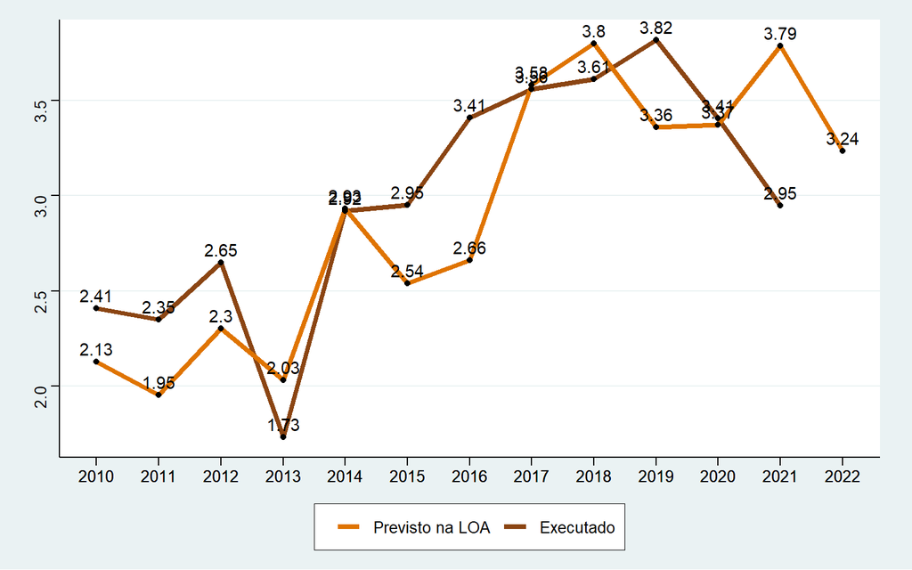

## 1.6 ASSISTÊNCIA SOCIAL:

**Função:** ASSISTENCIA SOCIAL

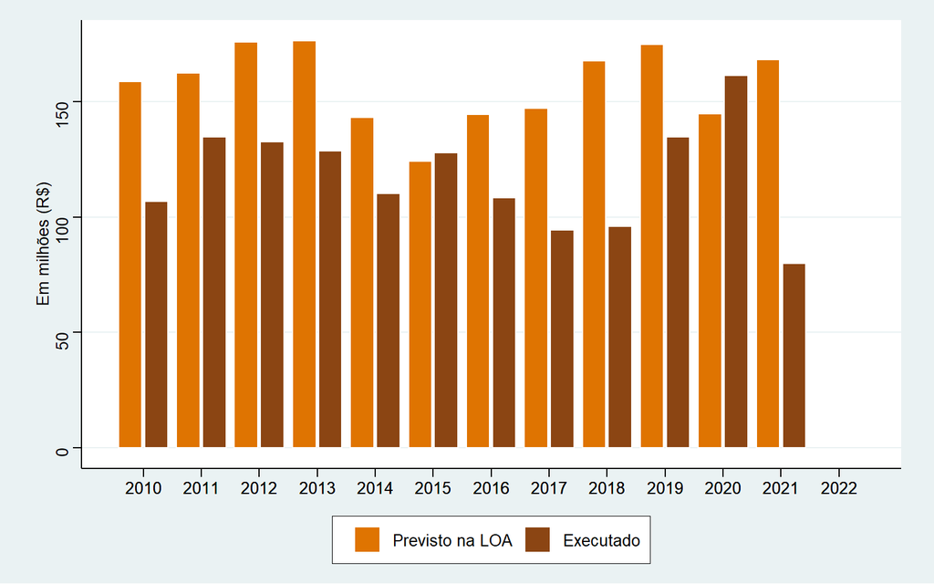

| ANO | PREVISTO NA LOA | EXECUTADO | LOA NOMINAL | EXECUTADO NOMINAL | % EXECUTADO |
| --- | --- | --- | --- | --- | --- |
| 2010 | R$ 158.668.545,06 | R$ 106.844.878,55 | R$ 86.105.362,00 | R$ 57.981.983,40 | 67.34 |
| 2011 | R$ 162.423.965,85 | R$ 134.599.555,88 | R$ 93.351.448,00 | R$ 77.359.664,11 | 82.87 |
| 2012 | R$ 175.733.648,55 | R$ 132.622.868,30 | R$ 107.569.501,00 | R$ 81.180.672,47 | 75.47 |
| 2013 | R$ 176.465.125,92 | R$ 128.566.815,59 | R$ 114.323.940,00 | R$ 83.292.746,00 | 72.86 |
| 2014 | R$ 143.139.388,27 | R$ 110.133.507,64 | R$ 98.214.864,00 | R$ 75.567.931,41 | 76.94 |
| 2015 | R$ 124.178.578,81 | R$ 127.811.461,36 | R$ 90.664.416,00 | R$ 93.316.831,40 | 102.93 |
| 2016 | R$ 144.560.303,59 | R$ 108.264.626,52 | R$ 116.810.270,00 | R$ 87.481.970,79 | 74.89 |
| 2017 | R$ 147.138.588,37 | R$ 94.393.636,25 | R$ 126.369.640,00 | R$ 81.069.758,54 | 64.15 |
| 2018 | R$ 167.742.761,69 | R$ 96.020.878,05 | R$ 148.311.704,00 | R$ 84.897.970,56 | 57.24 |
| 2019 | R$ 174.864.180,43 | R$ 134.685.889,78 | R$ 160.399.164,00 | R$ 123.544.479,32 | 77.02 |
| 2020 | R$ 144.618.454,50 | R$ 161.315.640,99 | R$ 138.367.751,00 | R$ 154.343.251,16 | 111.55 |
| 2021 | R$ 168.275.437,00 | R$ 79.963.382,86 | R$ 168.275.437,00 | R$ 79.963.382,86 | 47.52 |

**Valor previsto no PPA para 2022:** R$ 260.619.495,00

**Percentual de gasto em relação ao total das despesas:**

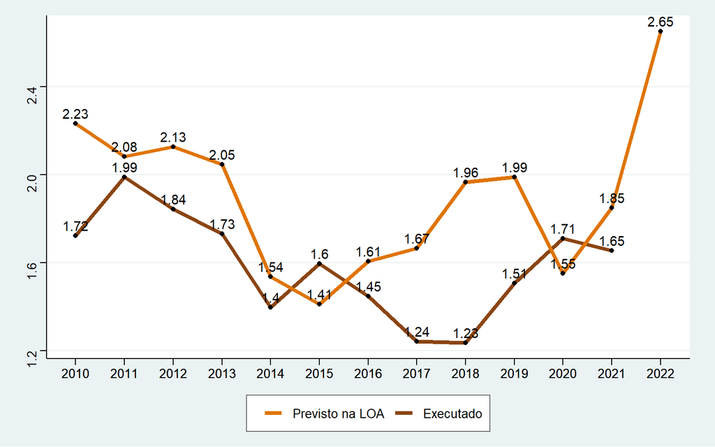

## 1.7 PREVIDENCIA SOCIAL:

**Função:** PREVIDENCIA SOCIAL

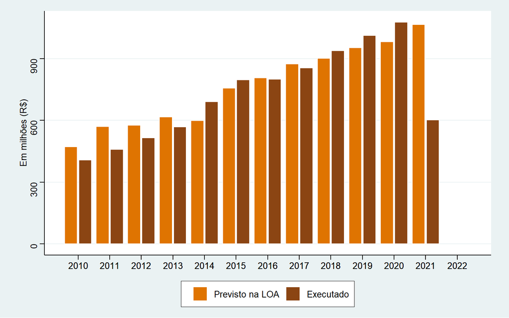

| ANO | PREVISTO NA LOA | EXECUTADO | LOA NOMINAL | EXECUTADO NOMINAL | % EXECUTADO |
| --- | --- | --- | --- | --- | --- |
| 2010 | R$ 471.997.604,05 | R$ 406.968.475,22 | R$ 256.141.030,00 | R$ 220.851.384,68 | 86.22 |
| 2011 | R$ 569.717.364,81 | R$ 458.261.949,69 | R$ 327.439.000,00 | R$ 263.381.184,80 | 80.44 |
| 2012 | R$ 576.687.419,39 | R$ 515.242.418,38 | R$ 353.000.000,00 | R$ 315.388.488,76 | 89.35 |
| 2013 | R$ 616.557.038,69 | R$ 568.782.035,91 | R$ 399.440.000,00 | R$ 368.488.691,50 | 92.25 |
| 2014 | R$ 598.218.094,86 | R$ 691.416.297,00 | R$ 410.466.396,00 | R$ 474.414.194,43 | 115.58 |
| 2015 | R$ 756.721.161,33 | R$ 796.615.005,15 | R$ 552.492.087,00 | R$ 581.619.107,83 | 105.27 |
| 2016 | R$ 807.220.600,91 | R$ 799.756.203,67 | R$ 652.265.207,00 | R$ 646.233.687,73 | 99.08 |
| 2017 | R$ 873.728.853,60 | R$ 854.715.771,49 | R$ 750.400.027,00 | R$ 734.070.684,93 | 97.82 |
| 2018 | R$ 901.339.815,63 | R$ 938.038.986,41 | R$ 796.930.029,00 | R$ 829.378.025,56 | 104.07 |
| 2019 | R$ 952.865.073,98 | R$ 1.013.106.601,67 | R$ 874.042.705,00 | R$ 929.300.966,90 | 106.32 |
| 2020 | R$ 981.178.156,89 | R$ 1.077.521.978,95 | R$ 938.769.643,00 | R$ 1.030.949.289,29 | 109.82 |
| 2021 | R$ 1.066.196.589,00 | R$ 602.849.281,30 | R$ 1.066.196.589,00 | R$ 602.849.281,30 | 56.54 |

**Valor previsto no PPA para 2022:** R$ 957.489.329,00

**Percentual de gasto em relação ao total das despesas:**

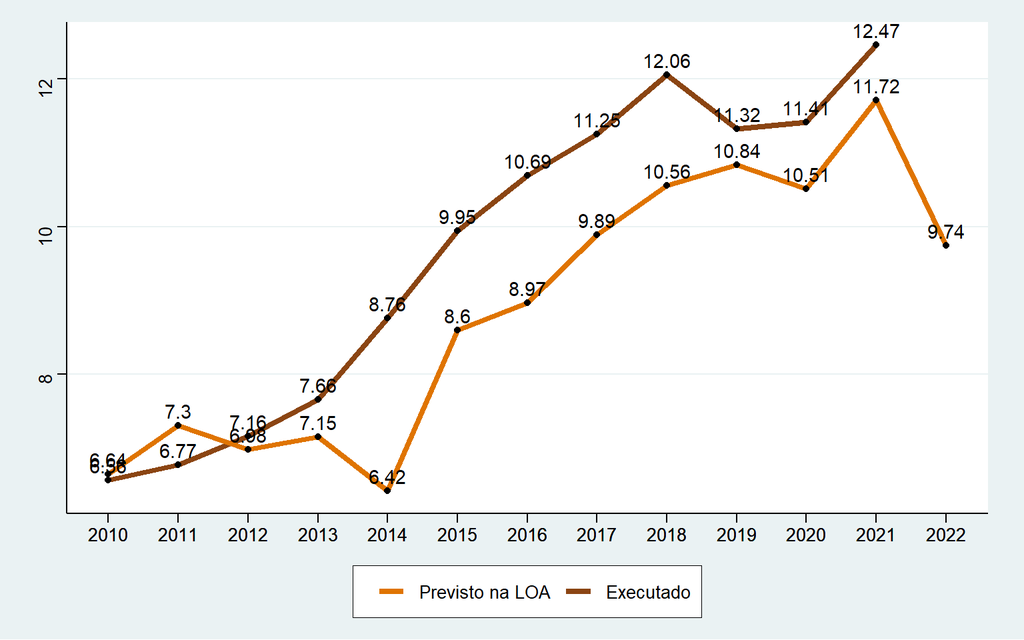

## 1.8 SAÚDE:

**Função:** SAUDE

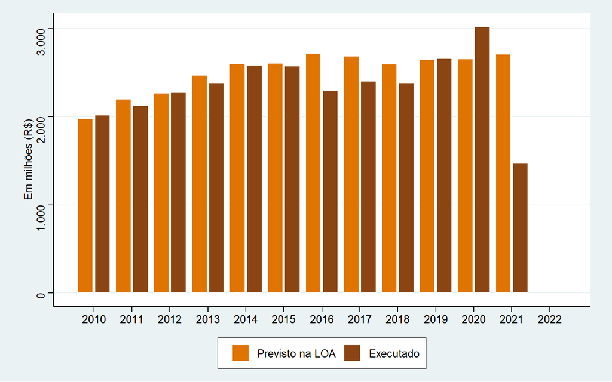

| ANO | PREVISTO NA LOA | EXECUTADO | LOA NOMINAL | EXECUTADO NOMINAL | % EXECUTADO |
| --- | --- | --- | --- | --- | --- |
| 2010 | R$ 1.979.779.766,12 | R$ 2.019.731.841,18 | R$ 1.074.375.853,00 | R$ 1.096.056.822,50 | 102.02 |
| 2011 | R$ 2.198.339.910,84 | R$ 2.128.456.508,01 | R$ 1.263.472.498,00 | R$ 1.223.307.755,00 | 96.82 |
| 2012 | R$ 2.267.321.878,90 | R$ 2.281.054.220,35 | R$ 1.387.865.586,00 | R$ 1.396.271.381,53 | 100.61 |
| 2013 | R$ 2.470.913.008,10 | R$ 2.386.756.299,66 | R$ 1.600.795.109,00 | R$ 1.546.273.704,64 | 96.59 |
| 2014 | R$ 2.600.741.476,61 | R$ 2.582.291.750,70 | R$ 1.784.494.635,00 | R$ 1.771.835.384,86 | 99.29 |
| 2015 | R$ 2.606.582.200,45 | R$ 2.573.249.667,97 | R$ 1.903.099.997,00 | R$ 1.878.763.476,00 | 98.72 |
| 2016 | R$ 2.717.069.415,91 | R$ 2.299.446.983,22 | R$ 2.195.496.303,00 | R$ 1.858.041.359,21 | 84.63 |
| 2017 | R$ 2.689.570.975,36 | R$ 2.401.902.543,00 | R$ 2.309.931.879,00 | R$ 2.062.868.503,99 | 89.30 |
| 2018 | R$ 2.598.945.804,41 | R$ 2.383.385.824,02 | R$ 2.297.888.010,00 | R$ 2.107.298.158,71 | 91.71 |
| 2019 | R$ 2.644.785.052,28 | R$ 2.661.335.272,34 | R$ 2.426.004.630,00 | R$ 2.441.185.792,06 | 100.63 |
| 2020 | R$ 2.656.656.387,93 | R$ 3.023.478.355,00 | R$ 2.541.830.300,00 | R$ 2.892.797.476,20 | 113.81 |
| 2021 | R$ 2.712.207.410,00 | R$ 1.476.052.737,00 | R$ 2.712.207.410,00 | R$ 1.476.052.737,00 | 54.42 |

**Valor previsto no PPA para 2022:** R$ 2.790.766.380,00

**Percentual de gasto em relação ao total das despesas:**

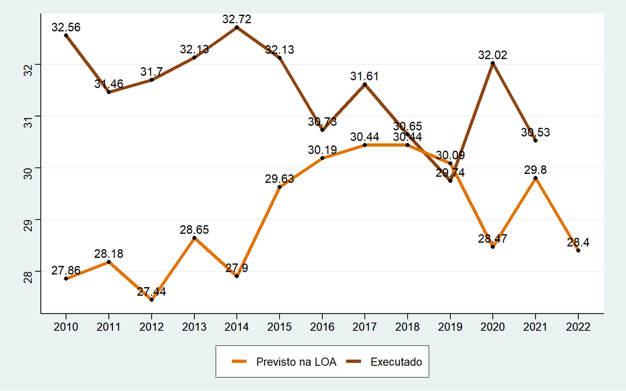

## 1.9 TRABALHO:

**Função:** TRABALHO

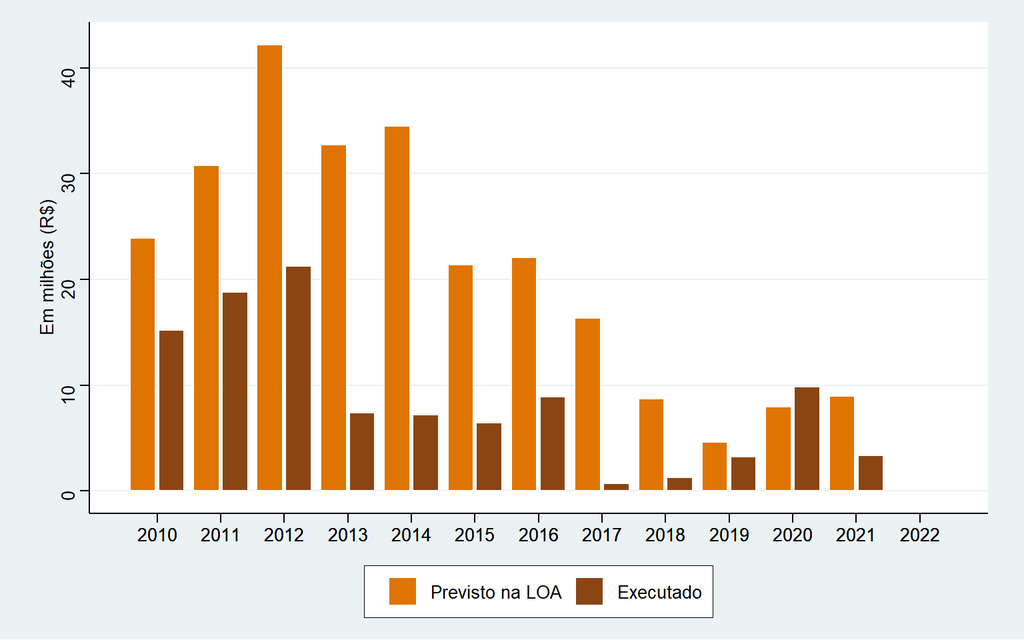

| ANO | PREVISTO NA LOA | EXECUTADO | LOA NOMINAL | EXECUTADO NOMINAL | % EXECUTADO |
| --- | --- | --- | --- | --- | --- |
| 2010 | R$ 23.919.160,96 | R$ 15.185.945,18 | R$ 12.980.317,00 | R$ 8.241.024,12 | 63.49 |
| 2011 | R$ 30.787.135,68 | R$ 18.783.220,61 | R$ 17.694.579,00 | R$ 10.795.456,40 | 61.01 |
| 2012 | R$ 42.201.627,58 | R$ 21.245.288,48 | R$ 25.832.321,00 | R$ 13.004.595,87 | 50.34 |
| 2013 | R$ 32.712.523,13 | R$ 7.412.277,69 | R$ 21.192.995,00 | R$ 4.802.086,45 | 22.66 |
| 2014 | R$ 34.469.299,32 | R$ 7.174.062,03 | R$ 23.651.055,00 | R$ 4.922.471,27 | 20.81 |
| 2015 | R$ 21.370.354,09 | R$ 6.451.369,14 | R$ 15.602.777,00 | R$ 4.710.229,58 | 30.19 |
| 2016 | R$ 22.062.484,88 | R$ 8.904.854,54 | R$ 17.827.334,00 | R$ 7.195.464,02 | 40.36 |
| 2017 | R$ 16.361.189,30 | R$ 733.454,02 | R$ 14.051.770,00 | R$ 629.925,31 | 4.48 |
| 2018 | R$ 8.710.586,66 | R$ 1.300.842,31 | R$ 7.701.566,00 | R$ 1.150.154,78 | 14.93 |
| 2019 | R$ 4.632.096,70 | R$ 3.215.681,40 | R$ 4.248.923,00 | R$ 2.949.675,61 | 69.42 |
| 2020 | R$ 7.968.934,55 | R$ 9.839.561,03 | R$ 7.624.501,00 | R$ 9.414.275,21 | 123.47 |
| 2021 | R$ 8.943.246,00 | R$ 3.375.956,79 | R$ 8.943.246,00 | R$ 3.375.956,79 | 37.75 |

**Valor previsto no PPA para 2022:** R$ 16.550.870,00

**Percentual de gasto em relação ao total das despesas:**

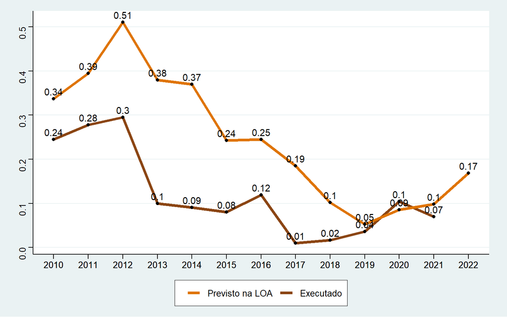

## 1.10 EDUCAÇÃO:

**Função:** EDUCACAO

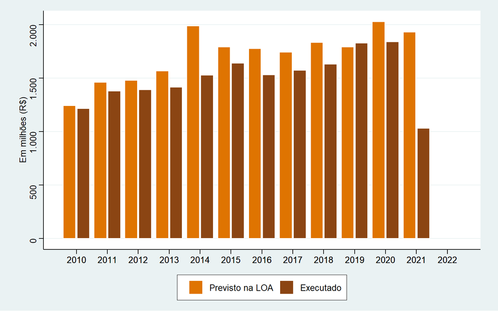

| ANO | PREVISTO NA LOA | EXECUTADO | LOA NOMINAL | EXECUTADO NOMINAL | % EXECUTADO |
| --- | --- | --- | --- | --- | --- |
| 2010 | R$ 1.242.143.478,08 | R$ 1.215.032.028,81 | R$ 674.079.502,00 | R$ 659.366.811,76 | 97.82 |
| 2011 | R$ 1.460.368.739,44 | R$ 1.380.215.362,78 | R$ 839.331.411,00 | R$ 793.264.109,70 | 94.51 |
| 2012 | R$ 1.479.415.608,54 | R$ 1.390.382.705,82 | R$ 905.575.000,00 | R$ 851.076.473,41 | 93.98 |
| 2013 | R$ 1.567.169.720,65 | R$ 1.417.028.039,64 | R$ 1.015.299.857,00 | R$ 918.029.711,18 | 90.42 |
| 2014 | R$ 1.990.267.741,65 | R$ 1.529.522.822,84 | R$ 1.365.619.051,00 | R$ 1.049.479.656,48 | 76.85 |
| 2015 | R$ 1.791.335.369,85 | R$ 1.639.688.948,61 | R$ 1.307.877.548,00 | R$ 1.197.158.498,45 | 91.53 |
| 2016 | R$ 1.777.748.299,90 | R$ 1.529.953.148,06 | R$ 1.436.488.813,00 | R$ 1.236.260.825,97 | 86.06 |
| 2017 | R$ 1.743.980.343,33 | R$ 1.572.241.099,39 | R$ 1.497.813.528,00 | R$ 1.350.315.671,24 | 90.15 |
| 2018 | R$ 1.835.375.876,94 | R$ 1.630.559.272,87 | R$ 1.622.768.822,00 | R$ 1.441.677.851,22 | 88.84 |
| 2019 | R$ 1.792.276.109,80 | R$ 1.828.194.072,01 | R$ 1.644.016.453,00 | R$ 1.676.963.229,74 | 102.00 |
| 2020 | R$ 2.029.636.733,23 | R$ 1.840.816.750,02 | R$ 1.941.911.709,00 | R$ 1.761.252.909,19 | 90.70 |
| 2021 | R$ 1.932.775.084,00 | R$ 1.032.611.559,00 | R$ 1.932.775.084,00 | R$ 1.032.611.559,00 | 53.43 |

**Valor previsto no PPA para 2022:** R$ 2.305.000.090,00

**Percentual de gasto em relação ao total das despesas:**

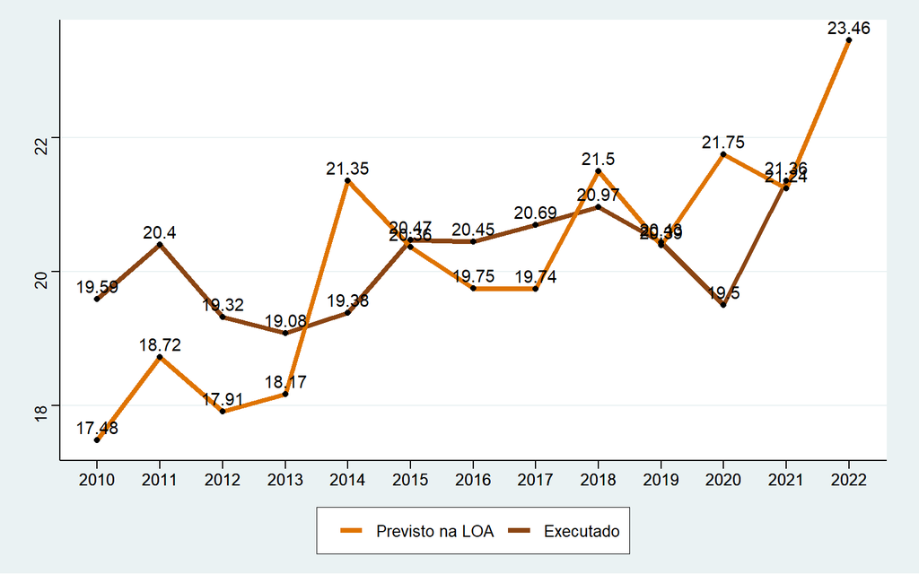

## 1.11 CULTURA:

**Função:** CULTURA

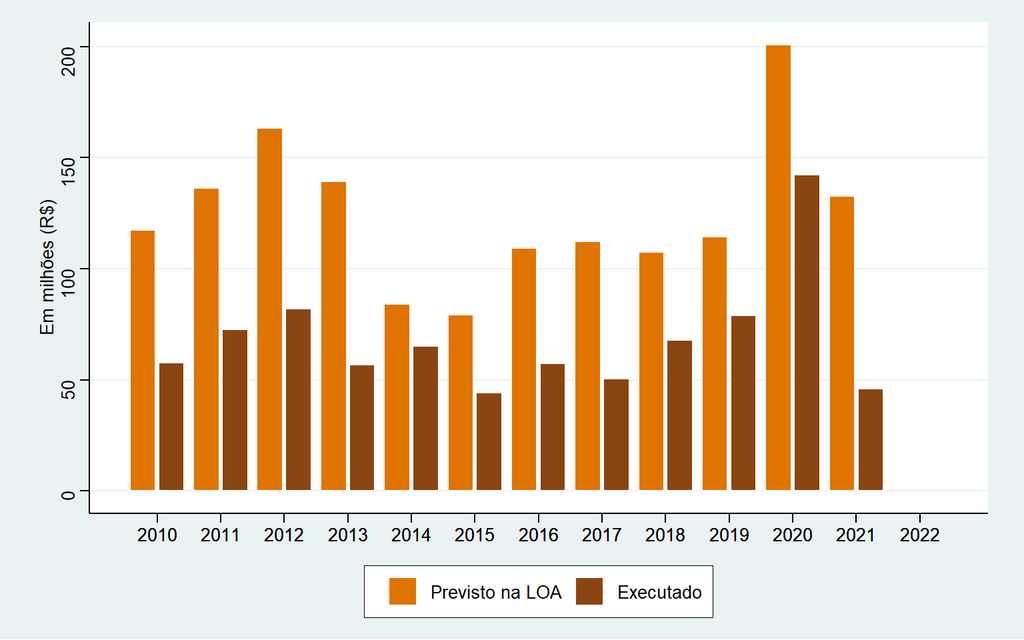

| ANO | PREVISTO NA LOA | EXECUTADO | LOA NOMINAL | EXECUTADO NOMINAL | % EXECUTADO |
| --- | --- | --- | --- | --- | --- |
| 2010 | R$ 117.511.610,39 | R$ 57.525.963,24 | R$ 63.770.546,00 | R$ 31.217.869,22 | 48.95 |
| 2011 | R$ 136.319.709,30 | R$ 72.661.612,68 | R$ 78.348.304,00 | R$ 41.761.489,58 | 53.30 |
| 2012 | R$ 163.141.459,83 | R$ 82.060.052,33 | R$ 99.861.612,00 | R$ 50.230.328,42 | 50.30 |
| 2013 | R$ 139.331.246,40 | R$ 56.682.155,15 | R$ 90.266.544,00 | R$ 36.721.858,05 | 40.68 |
| 2014 | R$ 84.013.045,82 | R$ 65.321.377,59 | R$ 57.645.418,00 | R$ 44.820.159,52 | 77.75 |
| 2015 | R$ 79.419.890,32 | R$ 44.179.167,63 | R$ 57.985.508,00 | R$ 32.255.792,19 | 55.63 |
| 2016 | R$ 109.399.065,51 | R$ 57.465.857,30 | R$ 88.398.641,00 | R$ 46.434.616,84 | 52.53 |
| 2017 | R$ 112.203.562,55 | R$ 50.471.986,37 | R$ 96.365.773,00 | R$ 43.347.750,02 | 44.98 |
| 2018 | R$ 107.524.619,85 | R$ 67.929.541,43 | R$ 95.069.137,00 | R$ 60.060.690,19 | 63.18 |
| 2019 | R$ 114.413.111,05 | R$ 78.830.953,13 | R$ 104.948.694,00 | R$ 72.309.943,34 | 68.90 |
| 2020 | R$ 200.909.082,85 | R$ 142.144.971,75 | R$ 192.225.384,00 | R$ 136.001.177,20 | 70.75 |
| 2021 | R$ 132.670.110,00 | R$ 45.915.785,82 | R$ 132.670.110,00 | R$ 45.915.785,82 | 34.61 |

**Valor previsto no PPA para 2022:** R$ 57.400.465,00

**Percentual de gasto em relação ao total das despesas:**

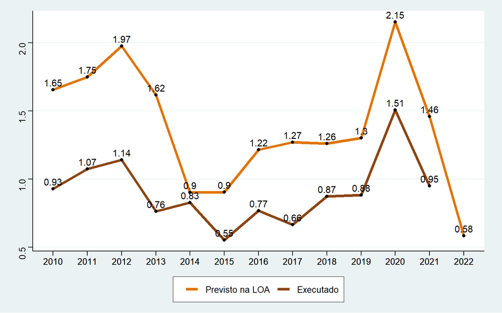

## 1.12 DIREITOS DA CIDADANIA:

**Função:** DIREITOS DA CIDADANIA

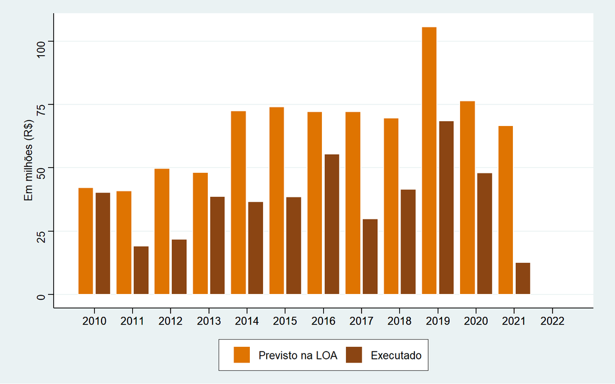

| ANO | PREVISTO NA LOA | EXECUTADO | LOA NOMINAL | EXECUTADO NOMINAL | % EXECUTADO |
| --- | --- | --- | --- | --- | --- |
| 2010 | R$ 42.124.776,48 | R$ 40.249.919,50 | R$ 22.860.039,00 | R$ 21.842.602,06 | 95.55 |
| 2011 | R$ 40.993.102,58 | R$ 19.071.384,47 | R$ 23.560.350,00 | R$ 10.961.075,52 | 46.52 |
| 2012 | R$ 49.680.123,10 | R$ 21.862.597,56 | R$ 30.410.033,00 | R$ 13.382.461,07 | 44.01 |
| 2013 | R$ 48.244.458,40 | R$ 38.676.625,89 | R$ 31.255.448,00 | R$ 25.056.873,05 | 80.17 |
| 2014 | R$ 72.481.413,80 | R$ 36.693.465,99 | R$ 49.733.007,00 | R$ 25.177.163,43 | 50.62 |
| 2015 | R$ 74.127.284,81 | R$ 38.484.723,29 | R$ 54.121.307,00 | R$ 28.098.203,37 | 51.92 |
| 2016 | R$ 72.146.764,56 | R$ 55.482.560,78 | R$ 58.297.353,00 | R$ 44.832.037,18 | 76.90 |
| 2017 | R$ 72.183.064,73 | R$ 29.872.307,45 | R$ 61.994.260,00 | R$ 25.655.762,91 | 41.38 |
| 2018 | R$ 69.655.967,75 | R$ 41.522.073,31 | R$ 61.587.130,00 | R$ 36.712.221,64 | 59.61 |
| 2019 | R$ 105.696.105,85 | R$ 68.617.393,22 | R$ 96.952.772,00 | R$ 62.941.263,79 | 64.92 |
| 2020 | R$ 76.452.452,36 | R$ 47.950.026,18 | R$ 73.148.022,00 | R$ 45.877.528,60 | 62.72 |
| 2021 | R$ 66.613.721,00 | R$ 12.729.972,46 | R$ 66.613.721,00 | R$ 12.729.972,46 | 19.11 |

**Valor previsto no PPA para 2022:** R$ 100.771.380,00

**Percentual de gasto em relação ao total das despesas:**

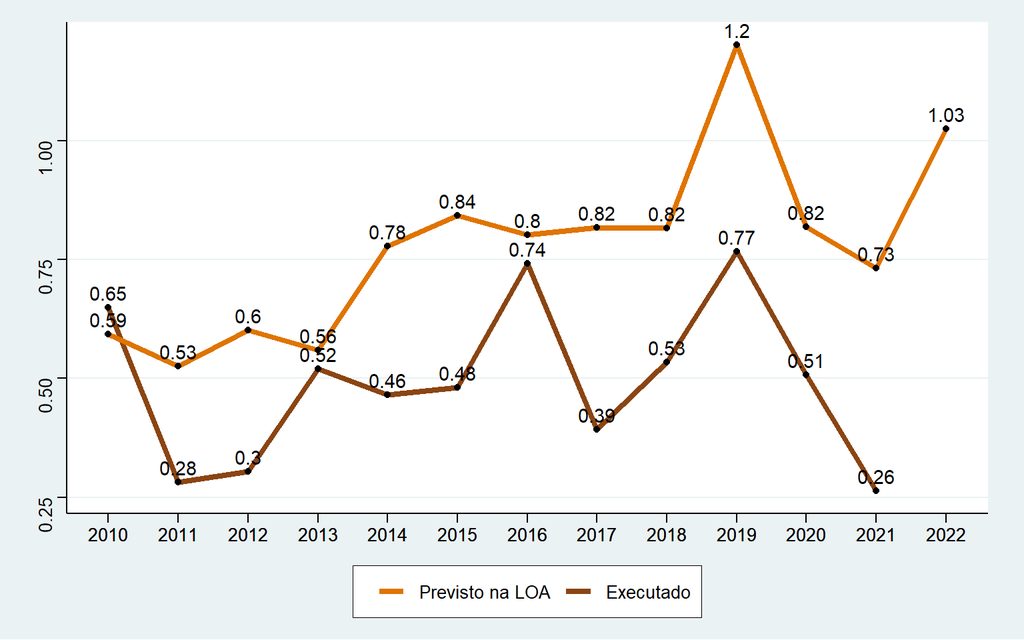

## 1.13 URBANISMO:

**Função:** URBANISMO

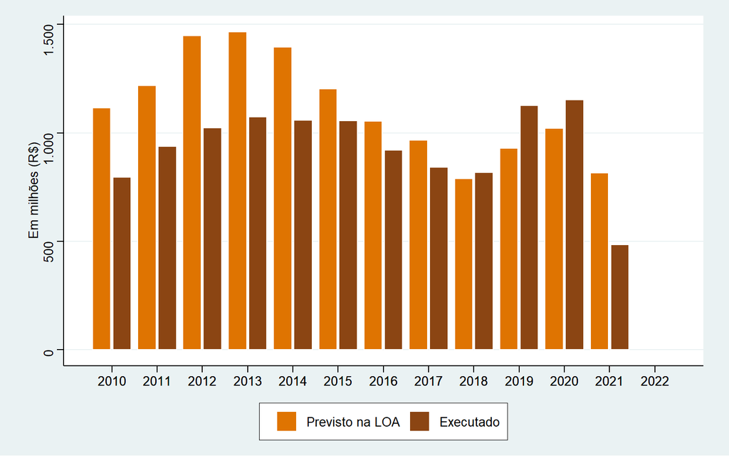

| ANO | PREVISTO NA LOA | EXECUTADO | LOA NOMINAL | EXECUTADO NOMINAL | % EXECUTADO |
| --- | --- | --- | --- | --- | --- |
| 2010 | R$ 1.115.025.861,36 | R$ 794.714.233,09 | R$ 605.096.022,00 | R$ 431.271.092,21 | 71.27 |
| 2011 | R$ 1.219.228.709,80 | R$ 937.494.589,40 | R$ 700.738.742,00 | R$ 538.815.050,80 | 76.89 |
| 2012 | R$ 1.448.833.551,22 | R$ 1.022.703.245,55 | R$ 886.855.212,00 | R$ 626.013.735,59 | 70.59 |
| 2013 | R$ 1.466.534.108,92 | R$ 1.073.828.528,25 | R$ 950.102.501,00 | R$ 695.685.946,97 | 73.22 |
| 2014 | R$ 1.395.988.373,39 | R$ 1.057.429.471,56 | R$ 957.855.206,00 | R$ 725.553.553,04 | 75.75 |
| 2015 | R$ 1.201.805.842,33 | R$ 1.055.024.282,60 | R$ 877.454.275,00 | R$ 770.287.124,92 | 87.79 |
| 2016 | R$ 1.053.135.714,48 | R$ 920.849.458,47 | R$ 850.974.051,00 | R$ 744.081.682,22 | 87.44 |
| 2017 | R$ 966.924.435,15 | R$ 840.384.153,85 | R$ 830.440.839,00 | R$ 721.762.007,91 | 86.91 |
| 2018 | R$ 789.339.225,41 | R$ 817.546.999,16 | R$ 697.903.411,00 | R$ 722.843.640,60 | 103.57 |
| 2019 | R$ 929.373.572,17 | R$ 1.125.833.145,19 | R$ 852.494.454,00 | R$ 1.032.702.608,66 | 121.14 |
| 2020 | R$ 1.021.161.447,98 | R$ 1.152.596.816,23 | R$ 977.024.775,00 | R$ 1.102.779.239,53 | 112.87 |
| 2021 | R$ 815.664.177,00 | R$ 483.528.718,70 | R$ 815.664.177,00 | R$ 483.528.718,70 | 59.28 |

**Valor previsto no PPA para 2022:** R$ 884.526.000,00

**Percentual de gasto em relação ao total das despesas:**

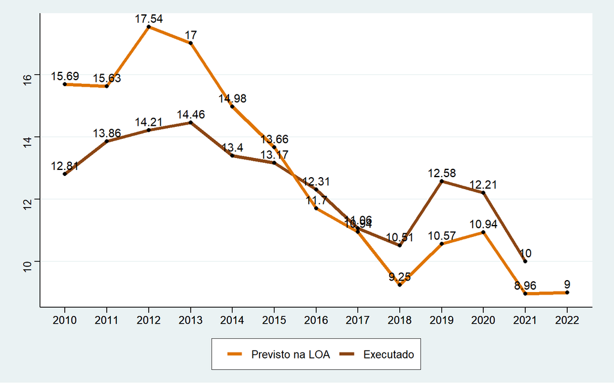

## 1.14 HABITAÇÃO:

**Função:** HABITACAO

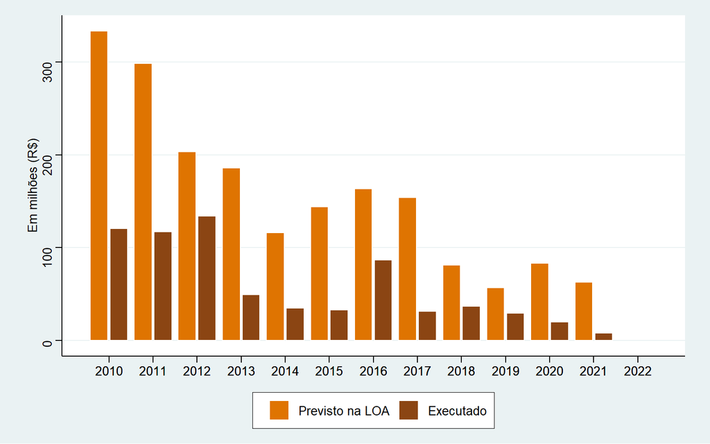

| ANO | PREVISTO NA LOA | EXECUTADO | LOA NOMINAL | EXECUTADO NOMINAL | % EXECUTADO |
| --- | --- | --- | --- | --- | --- |
| 2010 | R$ 333.502.532,12 | R$ 120.492.692,59 | R$ 180.983.296,00 | R$ 65.388.303,08 | 36.13 |
| 2011 | R$ 298.409.154,83 | R$ 117.023.743,13 | R$ 171.507.490,00 | R$ 67.258.152,54 | 39.22 |
| 2012 | R$ 203.124.340,56 | R$ 134.319.657,80 | R$ 124.335.801,00 | R$ 82.219.305,66 | 66.13 |
| 2013 | R$ 185.711.834,53 | R$ 49.252.114,45 | R$ 120.314.473,00 | R$ 31.908.263,73 | 26.52 |
| 2014 | R$ 115.939.447,75 | R$ 34.989.947,35 | R$ 79.551.668,00 | R$ 24.008.296,82 | 30.18 |
| 2015 | R$ 144.222.285,14 | R$ 32.931.599,57 | R$ 105.298.590,00 | R$ 24.043.794,60 | 22.83 |
| 2016 | R$ 163.492.422,21 | R$ 86.923.133,44 | R$ 132.108.148,00 | R$ 70.237.225,81 | 53.17 |
| 2017 | R$ 153.989.103,21 | R$ 31.614.898,67 | R$ 132.253.189,00 | R$ 27.152.383,39 | 20.53 |
| 2018 | R$ 81.281.814,56 | R$ 37.000.000,52 | R$ 71.866.257,00 | R$ 32.713.978,65 | 45.52 |
| 2019 | R$ 56.838.056,78 | R$ 29.615.963,47 | R$ 52.136.331,00 | R$ 27.166.088,39 | 52.11 |
| 2020 | R$ 83.328.718,56 | R$ 19.959.524,30 | R$ 79.727.082,00 | R$ 19.096.833,10 | 23.95 |
| 2021 | R$ 63.001.643,00 | R$ 7.993.510,72 | R$ 63.001.643,00 | R$ 7.993.510,72 | 12.69 |

**Valor previsto no PPA para 2022:** R$ 67.318.433,00

**Percentual de gasto em relação ao total das despesas:**

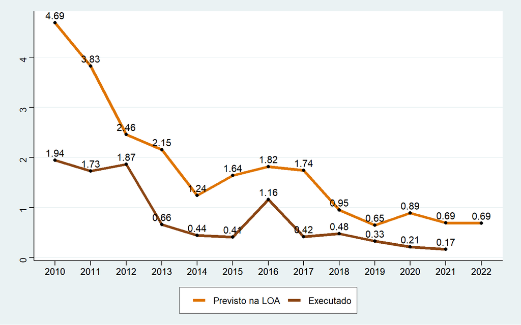

## 1.15 SANEAMENTO:

**Função:** SANEAMENTO

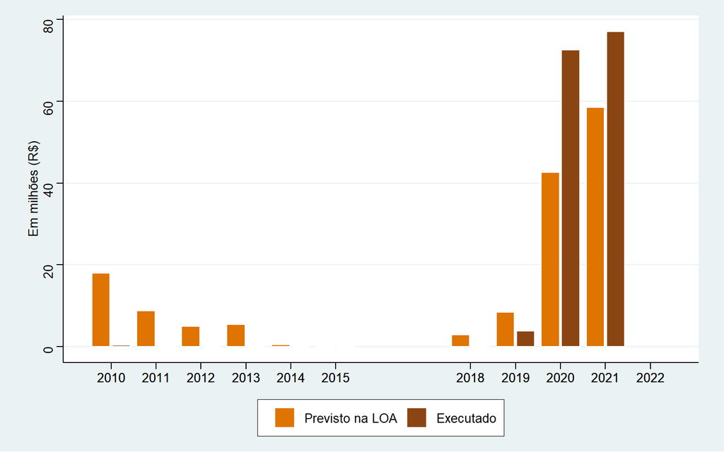

| ANO | PREVISTO NA LOA | EXECUTADO | LOA NOMINAL | EXECUTADO NOMINAL | % EXECUTADO |
| --- | --- | --- | --- | --- | --- |
| 2010 | R$ 17.918.679,21 | R$ 361.177,00 | R$ 9.724.009,00 | R$ 196.001,52 | 2.02 |
| 2011 | R$ 8.803.990,56 | R$ 264.122,40 | R$ 5.060.000,00 | R$ 151.801,54 | 3.00 |
| 2012 | R$ 5.019.992,10 | R$ 0,00 | R$ 3.072.821,00 | R$ 0,00 | 0.00 |
| 2013 | R$ 5.423.062,46 | R$ 0,00 | R$ 3.513.362,00 | R$ 0,00 | 0.00 |
| 2014 | R$ 510.093,73 | R$ 0,00 | R$ 350.000,00 | R$ 0,00 | 0.00 |
| 2015 | R$ 220.513,76 | R$ 0,00 | R$ 161.000,00 | R$ 0,00 | 0.00 |
| 2018 | R$ 2.940.639,00 | R$ 0,00 | R$ 2.600.000,00 | R$ 0,00 | 0.00 |
| 2019 | R$ 8.388.945,65 | R$ 3.780.233,04 | R$ 7.695.000,00 | R$ 3.467.526,73 | 45.06 |
| 2020 | R$ 42.619.605,98 | R$ 72.540.071,77 | R$ 40.777.500,00 | R$ 69.404.742,45 | 170.20 |
| 2021 | R$ 58.477.000,00 | R$ 77.046.316,30 | R$ 58.477.000,00 | R$ 77.046.316,30 | 131.75 |

**Valor previsto no PPA para 2022:** R$ 122.757.626,00

**Percentual de gasto em relação ao total das despesas:**

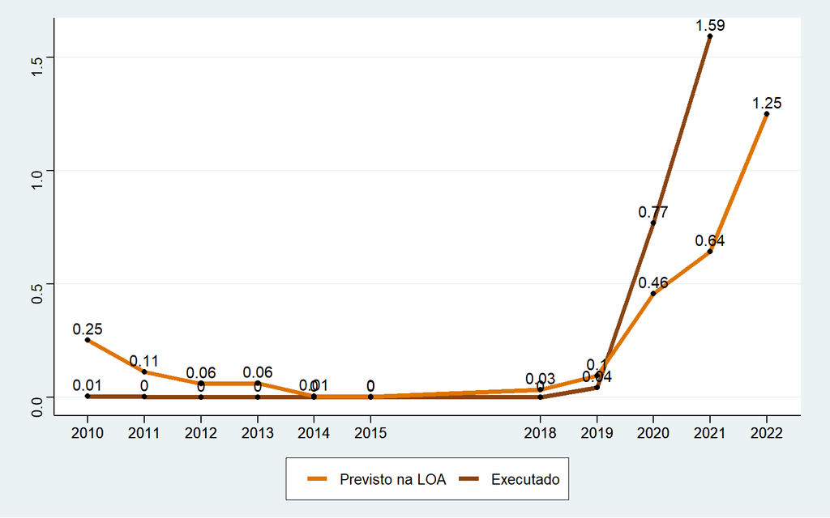

## 1.16 GESTÃO AMBIENTAL:

**Função:** GESTAO AMBIENTAL

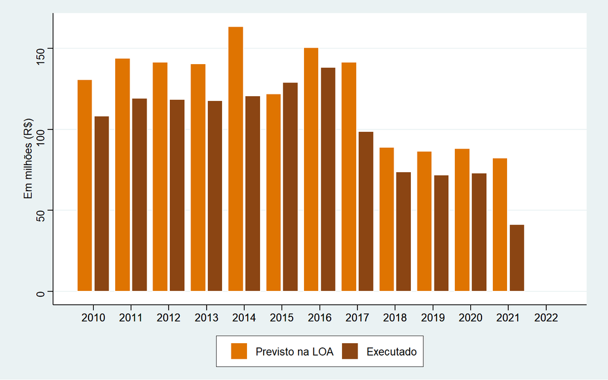

| ANO | PREVISTO NA LOA | EXECUTADO | LOA NOMINAL | EXECUTADO NOMINAL | % EXECUTADO |
| --- | --- | --- | --- | --- | --- |
| 2010 | R$ 130.574.866,42 | R$ 108.160.505,50 | R$ 70.859.641,00 | R$ 58.695.940,50 | 82.83 |
| 2011 | R$ 143.801.970,33 | R$ 119.228.851,90 | R$ 82.648.654,00 | R$ 68.525.515,37 | 82.91 |
| 2012 | R$ 141.502.362,25 | R$ 118.481.804,94 | R$ 86.615.959,00 | R$ 72.524.691,43 | 83.73 |
| 2013 | R$ 140.543.005,41 | R$ 117.701.962,31 | R$ 91.051.589,00 | R$ 76.253.888,73 | 83.75 |
| 2014 | R$ 163.482.220,45 | R$ 120.568.800,82 | R$ 112.173.066,00 | R$ 82.728.091,26 | 73.75 |
| 2015 | R$ 121.809.978,89 | R$ 128.836.724,77 | R$ 88.935.070,00 | R$ 94.065.389,72 | 105.77 |
| 2016 | R$ 150.515.111,26 | R$ 138.230.257,54 | R$ 121.621.983,00 | R$ 111.695.350,00 | 91.84 |
| 2017 | R$ 141.432.241,45 | R$ 98.765.322,76 | R$ 121.468.757,00 | R$ 84.824.371,50 | 69.83 |
| 2018 | R$ 88.904.373,84 | R$ 73.709.165,56 | R$ 78.605.831,00 | R$ 65.170.811,75 | 82.91 |
| 2019 | R$ 86.555.076,37 | R$ 71.834.159,80 | R$ 79.395.116,00 | R$ 65.891.934,82 | 82.99 |
| 2020 | R$ 88.181.449,45 | R$ 73.171.589,66 | R$ 84.370.068,00 | R$ 70.008.964,86 | 82.98 |
| 2021 | R$ 82.306.334,00 | R$ 41.396.452,92 | R$ 82.306.334,00 | R$ 41.396.452,92 | 50.30 |

**Valor previsto no PPA para 2022:** R$ 90.536.347,00

**Percentual de gasto em relação ao total das despesas:**

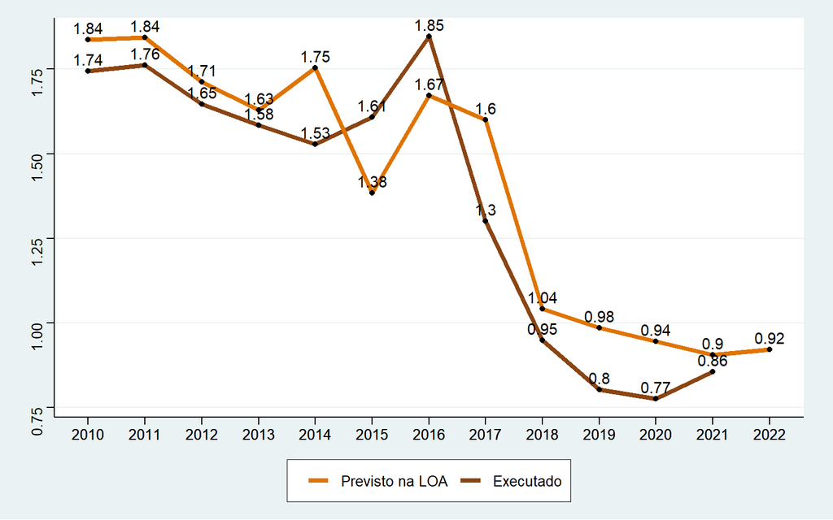